Data Visualization and Human Perception The Beginning of Science of Design Minji Kang

# 1 What is Data Visualization? Why is it Important?

Data Visualization is a visual representation, usually in graphical display, of an statistical information. Statistical information is abstract because it does not describe things that are not physical (Few 2013). Thus, the translation of abstract information into perceptual attributes facilitates the way we process information. Visualizing big and complex data through graphs and charts is easier than looking over spreadsheets or reports.

# 2 History of Data Visualization

A french philosopher and mathematician Rene Descartes was the first one to represent quantitative information graphically in the 17th century (Few 2013). He developed a two-dimensional coordinate systems called *Cartesian Coordinate System* composed of horizontal and vertical axis that maps two different variables in each axis (Few 2013).

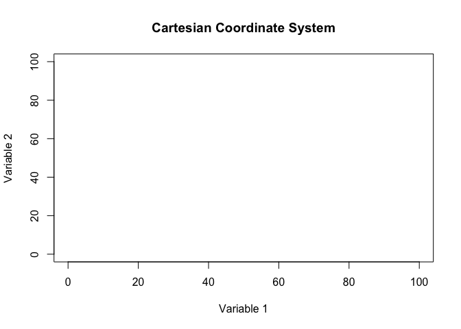

Figure 1:Cartesian Coordinate System generated in R

In the 18th century, Scotsman William Playfair invented line graphs, bar graphs, and pie charts (Few 2013). This was the beginning of graphical communication of quantitative data (Few 2013).

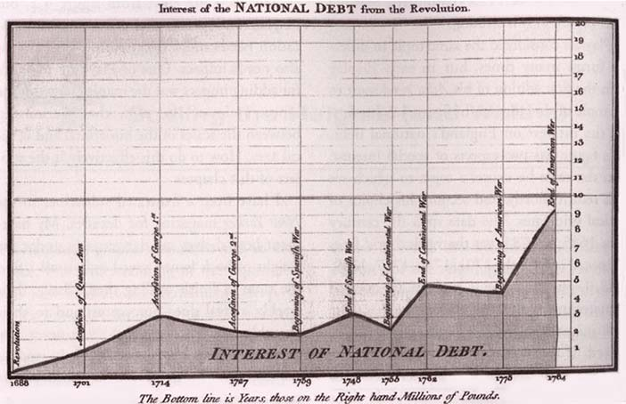

Figure 2: Playfair’s graph in “The Commercial and Political Atlas (1786)”

# 3 Data Visualization and Human Perception

The goal of Data Visualization is to translate abstract information into visual representation that can be decoded meaningfully by the perceive (Few 2013). A successful data visualization should help people understand the story behind the data and what they mean. Thus, data visualization take full advantage of the brain’s ability through balancing perception and cognition.

## 3.1 Theory of Perception

First, we explore the theory of perception by the Gestalt School of Psychology. The theory was developed to understand how people perceives patterns, forms, and organization. The resulting principle allowed interpretation of how the brain perceives meaningful information in a chaotic world. The six principles of perception are shown below:

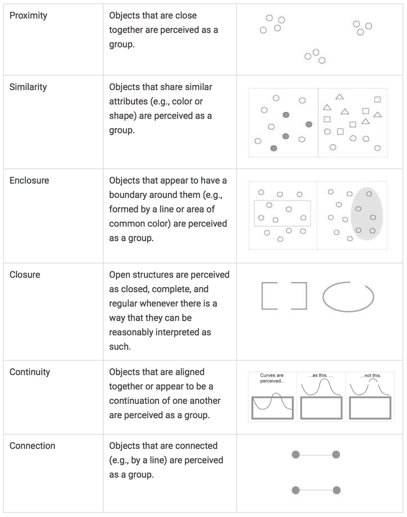

Figure 3: Gestalt Principles (Few, 2013)

### 3.1.1 Visual Cues

The discovery of Gastalt’s Theory of perception implies that the brain is wired to find patterns, forms, and organization in what we see. Since visualization is basically a mapping of data in different geometry and color, it is easy to lose the essence of data within the design (Yau 2013). Thus, Nathan Yau created a taxonomy of visual cues that help design data visualization in a meaningful way.

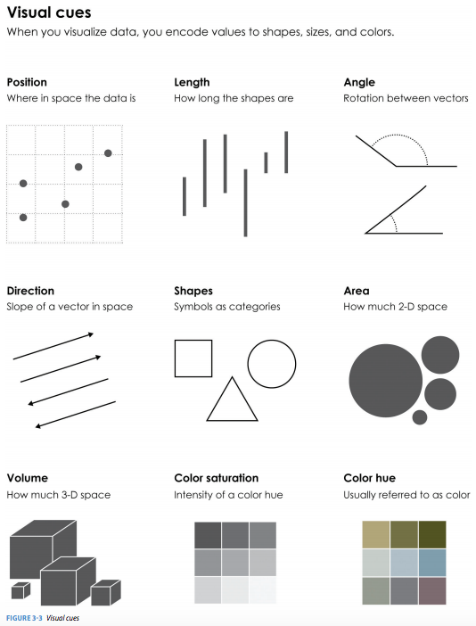

Figure 4: Visual Cues (Yau, 2013)

Visual cues of data visualization arises from preattentive visual processing. This process occurs automatically in the brain before conscious awareness (Few 2013). This automatic process consists of several stages by specialized neurons firing off and on to register particular attributes of visual information in relation to light reflecting off to the eyes(Few 2013). The basic attributes include:

- Length
- Size
- Hue
- Color Intensity
- Angle
- Texture
- Shape

These attributes also determine shadows, 3D orientations, and organized scattered elements accordingly like Gastalt’s Perception Theory (Few 2013). Proper use of visual cues allows less energy and results in more efficient cognition (Few 2013).

## 3.2 Cognitive Psychology

Not only do perception play a role in creating a effective visualization but also Cognitive psychology plays a role. As mentioned before, a successful visualization should be a balance between cognition and perception. The first step in understanding cognition is to understand the functionality of the brain as the brain is the center of information processing. The brain processes information through perception (by seeing), then registering the perception to cognition, and then performing an action to follow through the information processed (Hurtienne 2009).

**Simon Effect**. According to *Simon Effect*, “people respond faster and more accurate to stimulate that occurs in the same relative location as the response” (Sabeen Durrani 2009). This is true even if the location of information is irrelevant to the task (Sabeen Durrani 2009). There is an innate psychological tendency to respond towards the source of stimulus (Sabeen Durrani 2009). Interfaces should be designed following the congruent condition so that the location of stimuli and response is the same(Sabeen Durrani 2009). For example, if a task asks the user to press a button A if a image occurs on the left, and button B if a image occurs on the right, the buttons should correspond to the images (Sabeen Durrani 2009).

**Transference** Past Knowledge of user increases the perceiving ability and increases learning new concepts (Sabeen Durrani 2009). Interfaces should be designed accordingly to the expectations of the user and their behavior based on their past experience with prior interfaces (Sabeen Durrani 2009).

**Mental Imagery** Mental imagery is the mental expectation of how user imagines the design (Sabeen Durrani 2009). Thus, the interfaces should be in accordance with mental imagery to facilitate the user’s perception and processing(Sabeen Durrani 2009).

## 3.3 Activity Theory

The fundametal concept of Leontiev’s theory is that first, “activity” should be understood as “purposeful, social, mediated, multilevel, and developing interaction between actors and objective world”(Torkil Clemmensen 2016). Thus, the central claim of the theory is that activity should place the subject in objective reality and be able to transform the reality in a form of subjective world (Torkil Clemmensen 2016). Bødker (1989, 1991) employed this idea in design and analysis of computing technology to argue that designers need to take into account that people are *acting* through technology instead of *interacting* with it (Torkil Clemmensen 2016).

## 3.4 Prior Literature

### 3.4.1 The Eyes Have It: A Task by Data Type Taxonomy for Information Visualization

Ben Schneiderman introduced *Visual Information-Seeking Mantra* as a useful starting point in designing advanced interactive visual graphics. However the mantra only serves as a starting point in understanding “rich and varied set of information visualization” (Shneiderman 1996). Thus, he also presents data type taxonomy to further analyze the different data types and tasks associated with data types.

With the use of the *Visual Information-Seeking Mantra*, abstract information visualization has the power to display patterns, clusters, gaps, or outliers in statistical data (Shneiderman 1996). To sort out and guide the presentation of visual information, Schneiderman proposes a type by task taxonomy of information visualization. According to the Mantra, there are seven tasks that are used at high level of abstraction:

- **Overview**: View of the entire collection of information visualization (Shneiderman 1996).
- **Zoom**: magnify into items of interest (Shneiderman 1996).
- **Filter**: refine items of interest (Shneiderman 1996).
  - Often used in dynamic queries. Filtering allows the users to control the contents of display, so the users can quickly focus on items of interest and disregard unwanted items (Shneiderman 1996).
- **Details-on-demand**: Select items or groups to display details when needed.
  - Often utilized as a tooltip, simply click on an item to attain details.
- **Relate**: Display relationship among items (Shneiderman 1996).
  - If a user selects an item of interest, the visual graphic will highlight items with similar attributes (Shneiderman 1996).
- **History**: Collect history of actions to allow undo and replay actions (Shneiderman 1996).
  - When interacting with an interface, it is rare the user’s action produce desired outcome. Thus keeping the history allow users to retrace their steps (Shneiderman 1996).
- **Extract**: Allow extraction of the parameters of interest (Shneiderman 1996).
  - Once the user has obtained the item of set of items of interest, extract will allow users to extract the items and save it in a file (Shneiderman 1996).

These seven tasks can then be applied to different data types listed as:

- **1-dimensional**: linear data types.
  - textual documents, programming source code, alphabetical lists (Shneiderman 1996).
  - With such data type, the interface design could include different fonts, sizes, and colors (Shneiderman 1996). In addition, the overview of linear data types can include scrolling and filtering by sections (Shneiderman 1996).
- **2-dimensional**: planar or map data
  - geographic maps, floor plans, cartesian coordinate systems (Shneiderman 1996).
  - With such data types, the interface design could include filtering, details-on-demand, or relate as the the user may have problems finding items or paths between items (Shneiderman 1996).
- **3-dimensional**: real world tangible objects.
  - molecules, human body, buildings, items with volume (Shneiderman 1996).
  - With 3-dimensional data types, users needs to understand and deal with their orientation when viewing the data type (Shneiderman 1996). Thus, the interface design techniques needs to utilize overviews, landmarks, zoom, and details-on-demand (Shneiderman 1996).
- **Temporal**: Items have a start and finish time (Shneiderman 1996).
  - With such data type, overview is necessary with selectable items to get details-on-demand (Shneiderman 1996).
- **Multi-dimensional**: relational and statistical data types usually have items with multiple attribute such that points are in an n-dimensional space.
- For such data type, slider bars and buttons can used to show details-on-demand (Shneiderman 1996). In addition, the visual cues (discussed above) can be used to display the different attributes of the points.
- **Tree**: collection of items hierarchical link to a root item (Shneiderman 1996).
  - Basic tasks can be applied to items and links (Shneiderman 1996). The tasks that can relate structural properties can be useful as well (Shneiderman 1996).
- **Network**: collection of items “linked to an arbitrary number of other times” (Shneiderman 1996).
- Basic tasks can be applied to items, links, and pathways of the network (Shneiderman 1996).

### 3.4.2 Interactive Data Graphics and Information Processing

Wojdynksi (2014) examined the effects of interactivity in understanding online health news with data graphics. The experiment contained three different levels of interactivity in the data graphics: low, medium, and high, and a text of the online health news (Wojdynski 2014). The low condition displayed static graphs that displayed changes between 1996 and 2009 taking 1 prescription drug, changes between 1996 and 2009 taking 3 or more prescription drugs, and 3 separate other static graphs that displayed changes in US lifespan from 1900 to 2010 for males, females, all US population (Wojdynski 2014). The medium condition displayed graphics that allowed the users to control the pace of information with the use of next/back button (interactivity) of the 5 different graphs that were displayed in the low condition (Wojdynski 2014). The high condition allowed the user to control both the pace and the content (interactivity) of display with the drop down menu of the 5 data graphics displayed in the low condition (Wojdynski 2014).

After having been exposed to the different conditions, the participants completed measures assessing their recall of statistical information presented to them (Wojdynski 2014). Participants were also asked to rate their attitudes toward the the content of the health information as well as perceive interactivity and involvement (Wojdynski 2014).

The results indicated that interactivity increased recall of statistical information for those with less prior knowledge, while those with higher prior knowledge had no effect of recall despite interactivity (Wojdynski 2014). The effects of interactivity on attitudes were also found to be mediated by perceived interactivity (Wojdynski 2014). The perceived interactivity mediated the effects of interactivity on attitudes (Wojdynski 2014).

### 3.4.3 Exemplification and Interactivity effect on shaping perception and attitude of social issues

Jia (2014) studied whether interactive visualization of data graphics in news articles allowed higher information processing than static visualization of data graphics. By requiring the users to interact with the visualization, it could increase attention to the data graphics in news articles and also facilitate their understanding and engagement with data rich contents (Jia 2014).

The study was conducted using a 2 (graphic and text consistency) x 3 (interactivity of information visualization) x 2 (issue topic) mixed design experiment (Jia 2014). The participants of the study were asked to read a news reports either about climate change and same-sex marriage with one of the three levels of information visualization (verbal, static, or interactive) that were either consistent or not consistent with the text information (Jia 2014). The participants were randomly sampled to topic of news article, level of interactivity, and consistency (Jia 2014).

The results of the study revealed that interactive visualization was positively associated with emotional response and increased perceived vividness and user engagement with the news content (Jia 2014). It was also revealed that interactive visualization is effective in motivating systematic processing of data graphics, and positively influences the accuracy of news perception as well as personal attitude about the news content, compared to the static visualization (Jia 2014).

# 4 Research

The effectiveness of data visualization is mainly determined by the creator’s intentions and the audience’s needs. The design of visualization should feature the information in a clear and useful way. Because any quantitative information can be visualized in many different ways, the meaning contained within the visualization should translate the information that the creator chose to communicate effectively.

Visualizing data is a form of cognitive metaphor (Few 2013). Visual display of data is not a literal physical representation of the numbers but a metaphor of what may be the meaning behind these numbers. Thus, experimentation is necessary to further explore and evaluate powerful methods of visualization.

Although Data Visualization is known to be a facilitated process of understanding abstract statistical information, not much research have shown the effects of interactivity as improved means of data visualization. Thus, for my research I will be specifically explore the effects of interactivity in comparison to static representation of data.

## 4.1 Method

### 4.1.2 Measures

**Post Task Questionnaire.** Multiple Regression quiz to test their learning.

The participants were given six questions on their understanding of the visual graphics presented to them. The questions inquired whether they understood how to interpret the slope and the intercepts, if there were an interaction, etc. Then, the number of questions that the participants correctly answered was computed.

**Post Task Satisfaction** A short survey to gauge their satisfaction with the model.

### 4.1.3 Procedure

The study was conducted through an anonymous Qualtrics link. The participants were randomly assigned into two different data visualization (Interactive vs static information on the screen) shown below. The both visualization was created through `ggplot2` package (Wickham 2009) and the interactive visualization was created through `plotly` package (Inc. 2015).

Static Data Visualization

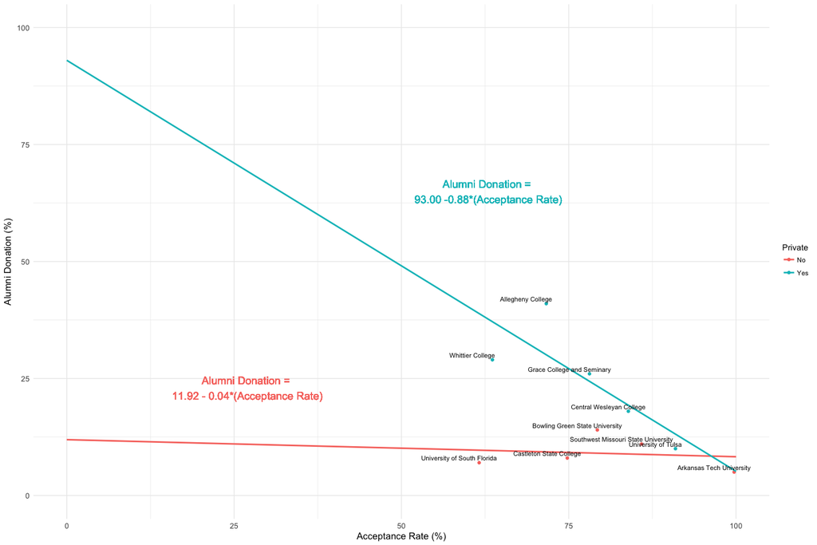

Interactive Data Visualization

[interactive chart not shown]

Then, participants were asked to complete the post task questionnaire as well as post task satisfaction.

## 4.2 Results

### 4.2.1 Preliminary Analysis

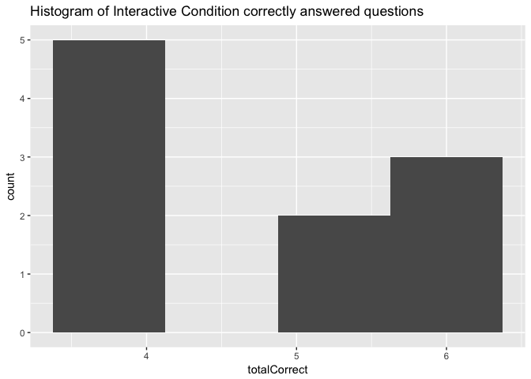

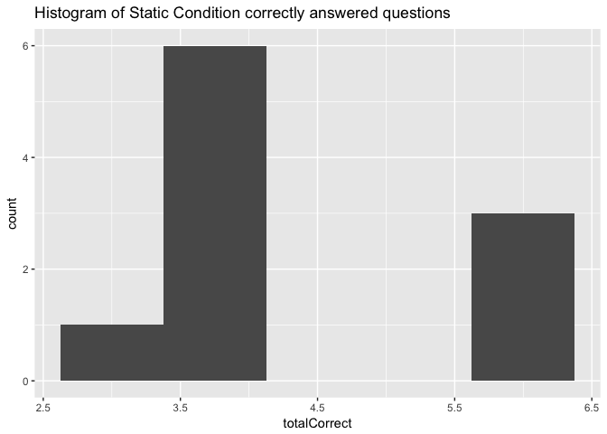

```
##     Condition min Q1 median   Q3 max mean        sd  n missing
## 1 Interactive   4  4    4.5 5.75   6  4.8 0.9189366 10       0
## 2      Static   3  4    4.0 5.50   6  4.5 1.0801234 10       0
```

The histogram of number of correct questions in the post task questionnaire in interactive and static conditions were not normally distributed as shown above, $Mdn = 4.5$, $IQR =1.74$, and $Mdn = 4.0$, $IQR = 1.5$ respectively. Due to the skewed distributions, there are possible threats to the assumption of normality. In addition, the small sample size also poses as a possible threat to the assumption of large sample size.

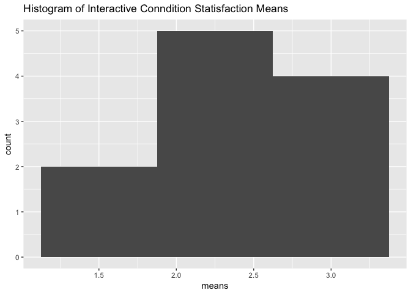

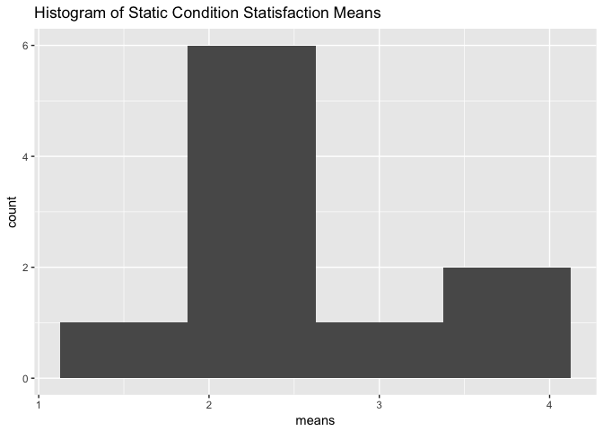

```
##     Condition      min       Q1   median       Q3      max     mean
## 1 Interactive 1.666667 1.944444 2.111111 2.722222 3.111111 2.323232
## 2      Static 1.777778 2.027778 2.222222 2.638889 3.666667 2.477778
##          sd  n missing
## 1 0.5029654 11       0
## 2 0.6543093 10       0
```

The histogram of number of satisfaction means of the post satisfaction questionnaire in interactive and static condition are fairly normality distributed, $M = 2.32$, $Sd = 0.50$. While, the histogram of satisfaction means of the post satisfaction questionnaire in the static condition is skewed, $Mdn = 2.2$, $IQR = 0.611$. Due to the skewed distribution, there are possible threats to the assumption of normality. In addition, the small sample size also poses as a possible threat to the assumption of large sample size.

### 4.2.2 Main Results

The current study seek to understand whether interactive interface is effective in increasing the level of understanding as well as satisfaction with the model. I conducted an independent T-test to evaluate whether the average number of correct questions was different between the two conditions.

```
##
##  Welch Two Sample t-test
##
## data:  totalCorrect by Condition
## t = 0.66896, df = 17.549, p-value = 0.5122
## alternative hypothesis: true difference in means is not equal to 0
## 95 percent confidence interval:
##  -0.6439038  1.2439038
## sample estimates:
## mean in group Interactive      mean in group Static
##                       4.8                       4.5
```

The results of the data suggest that the average number of correct question is not statistically different for static or interactive condition ($p > 0.05$). This suggests that there isn’t a difference level of understanding of the model depending on the level of interactivity

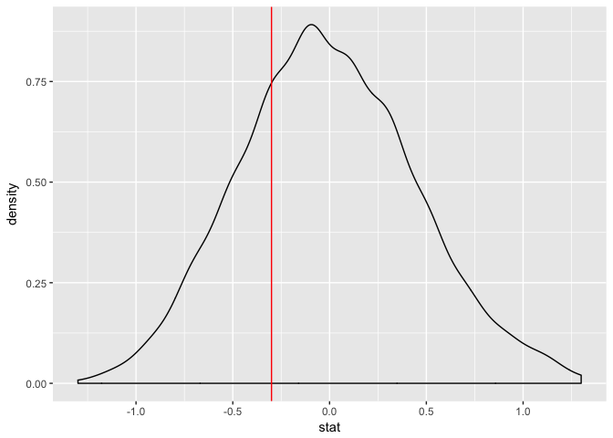

```
## # A tibble: 1 x 1
##   p_value
##     <dbl>
## 1   0.386
```

Due to the small sample size, a bootstrap test was conducted as well. However, the bootstrap test also indicates that the average number of correct question is not statistically different for static or interactive condition ($p > 0.05$). This further suggests that there isn’t a difference in level of understanding of the model depending on the level of interactivity.

```
##
##  Welch Two Sample t-test
##
## data:  means by Condition
## t = -0.60244, df = 16.882, p-value = 0.5549
## alternative hypothesis: true difference in means is not equal to 0
## 95 percent confidence interval:
##  -0.6960735  0.3869826
## sample estimates:
## mean in group Interactive      mean in group Static
##                  2.323232                  2.477778
```

The results of the data suggest that the average satisfaction is not statistically different for static or interactive condition ($p > 0.05$). This suggests that there isn’t a difference in data visualization satisfaction depending on the level of interactivity.

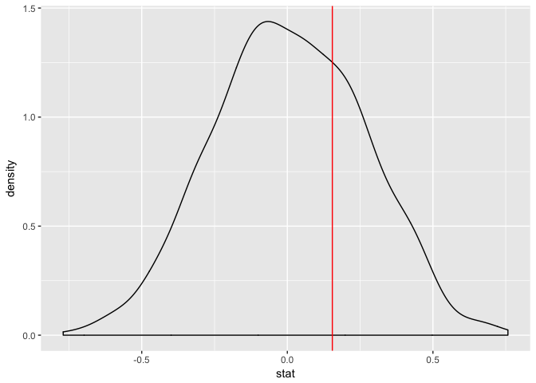

```
## # A tibble: 1 x 1
##   p_value
##     <dbl>
## 1   0.594
```

# 5 Conclusion

The results of the study may be due to the fact that there were not enough sample to compute the difference of means. However, the current study did not find a statistically significant result indicating that visual graphic presented with interactivity increases the level of understanding the statistical data nor user satisfaction.

# References

Few, Scott. 2013. *Data Visualization for Human Perception*. 2nd ed. https://www.interaction-design.org/literature/book/the-encyclopedia-of-human-computer-interaction-2nd-ed/data-visualization-for-human-perception.

Hurtienne, Jörn. 2009. “Cognition in Hci: An Ongoing Story” 5 (1).

Inc., Plotly Technologies. 2015. “Collaborative Data Science.” Montreal, QC: Plotly Technologies Inc. 2015. https://plot.ly.

Jia, Haiyan. 2014. “Big Data or Small Stories? Exemplificiation and Interactivity Effects on Shaping Perception and Attitude of Social Issues.” PhD thesis, Pennsylvania State University.

Leontiev, Aleksei N. 1978. *Activity, Consciousness, and Personality*. Vol. 44.

Miller, George A. 1956. “The Magical Number Seven, Plus or Minus Two: Some Limits on Our Capacity for Processing Information.” *Psychological Review* 63.

Sabeen Durrani, Qaiser S. Durrani. 2009. “Applying Cognitive Psychology to User Interfaces.” *Proceedings of the First International Conference on Intelligent Human Computer Interaction*.

Shneiderman, Ben. 1996. “The Eyes Have It: A Task by Data Type Taxonomy for Information Visualizations.” *Proceedings of the 1996 IEEE Symposium on Visual Languages*. College Park, Maryland.

Torkil Clemmensen, Bonnie Nardi, Victor Kaptelinin. 2016. “Making Hci Theory Work: An Analysis of the Use of Activity Theory in Hci Research.” *Behaviour & Information Technology* 35.

Wickham, Hadley. 2009. *Ggplot2*. New York, NY. http://ggplot2.org.

Wojdynski, Bartosz W. 2014. “Interactive Data Graphics and Information Processing: The Moderating Role of Involvement.” *Journal of Media Psychology: Theories, Methods, and Applications* 27 (1). Athens, GA.

Yau, Nathan. 2013. *Representing Data*.